# DataCapstone Week 1 & 2

## Coursera Data Science Capstone - WEEK I & WEEK II Tasks

## WEEK I

The goal of this capstone is to mimic the experience of being a data scientist by using data science techniques learned from all 9 specialization courses to create a data product and presentation to Swiftkey.

For Week 1, the main objective is to understand the problem, acquire the data, and understand the type of data we dealing with. The data is available to be downloaded from

https://d396qusza40orc.cloudfront.net/dsscapstone/dataset/Coursera-SwiftKey.zip

The files are extracted from the zip file with three working files:

- “en_US.blogs.txt”
- “en_US.news.txt”
- “en_US.twitter.txt”

### Data Loading

Several library chosen to begin with are as below:

```r
library(magrittr)
library(stringi)
library(ggplot2)
library(wordcloud)
library(tm)
library(SnowballC)
library(RWeka)
library(dplyr)
#setwd("Coursera X - Final Capstone/")
blogfile<- "Coursera-SwiftKey/final/en_US/en_US.blogs.txt"
newsfile<- "Coursera-SwiftKey/final/en_US/en_US.news.txt"
twitterfile<- "Coursera-SwiftKey/final/en_US/en_US.twitter.txt"
```

### Data Basic Exploring

Let’s count number of lines and words by dataset

```r
blogLines<-readLines(blogfile,encoding="UTF-8", skipNul = TRUE)
newsLines<-readLines(newsfile,encoding="UTF-8", skipNul = TRUE)
twitterLines<-readLines(twitterfile,encoding="UTF-8", skipNul = TRUE)

blogWords<-stri_count_words(blogLines)
newsWords<-stri_count_words(newsLines)
twitterWordst<-stri_count_words(twitterLines)
```

### Blog

Number of lines / Number of Words

```r
length(blogLines)
```

```
## [1] 899288
```

```r
sum(blogWords)
```

```
## [1] 37546239
```

### Twitter

Number of lines / Number of Words

```r
length(twitterLines)
```

```
## [1] 2360148
```

```r
sum(twitterWordst)
```

```
## [1] 30093413
```

### News

Number of lines / Number of Words

```r
length(newsLines)
```

```
## [1] 77259
```

```r
sum(newsWords)
```

```
## [1] 2674536
```

## Week 1 - Quiz Questions

### 1. Question

The en_US.blogs.txt file is how many megabytes?

```r
FileInfo <- file.info(blogfile)
sizeB <- FileInfo$size
sizeKB <- sizeB/1024
sizeMB <-  sizeKB/1024
sizeMB
```

```
## [1] 200.4242
```

### 2. Question

The en_US.twitter.txt has how many lines of text?

```r
length(twitterLines)
```

```
## [1] 2360148
```

### 3. Question

What is the length of the longest line seen in any of the three en_US data sets? Counting Blog file

```r
summary(nchar(blogLines))
```

```
##    Min. 1st Qu.  Median    Mean 3rd Qu.    Max.
##       1      47     156     230     329   40833
```

```r
summary(nchar(newsLines))
```

```
##    Min. 1st Qu.  Median    Mean 3rd Qu.    Max.
##     2.0   111.0   186.0   202.4   270.0  5760.0
```

```r
summary(nchar(twitterLines))
```

```
##    Min. 1st Qu.  Median    Mean 3rd Qu.    Max.
##    2.00   37.00   64.00   68.68  100.00  140.00
```

### 4. Question

In the en_US twitter data set, if you divide the number of lines where the word “love” (all lowercase) occurs by the number of lines the word “hate” (all lowercase) occurs, about what do you get?

```r
lovelines <- (grepl(" love ", twitterLines))
numlove <- table(lovelines)["TRUE"]

hatelines <- (grepl(" hate ", twitterLines))
numhate <- table(hatelines)["TRUE"]

proportion <- numlove/numhate
proportion
```

```
##     TRUE
## 4.616849
```

### 5. Question

The one tweet in the en_US twitter data set that matches the word “biostats” says what?

```r
lineTarget <- grep("biostats",twitterLines)
twitterLines[lineTarget]
```

```
## [1] "i know how you feel.. i have biostats on tuesday and i have yet to study =/"
```

### 6. Question

How many tweets have the exact characters “A computer once beat me at chess, but it was no match for me at kickboxing”. (I.e. the line matches those characters exactly.)

```r
grep("A computer once beat me at chess, but it was no match for me at kickboxing", twitterLines)
```

```
## [1]  519059  835824 2283423
```

## Week 2 - Exploratory Data Analysis

As we have just seen in the Week I, files are too big. Therefore, for this task of exploratory data, I will take a sample of the data. Moreover, we will pass some “tm package” functions to clean the data:

- Ensure the data is ASCII.
- To lowercase.
- Digits, puntuation, stopwords, white spaces will be elimated

Finally, it is time now to create some plots to explore the data. Firstly, let’s create some histograms to deal with frecuency of nGrams

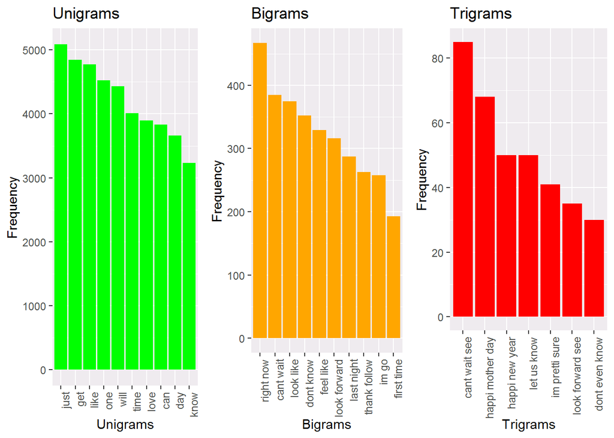

```r
set.seed(1414)
data_blogs <- iconv(blogLines,  to="ASCII", sub="")
data_news <- iconv(newsLines,  to="ASCII", sub="")
data_twitter <- iconv(twitterLines,  to="ASCII", sub="")

#to remove emojis
data_blogs <- iconv(data_blogs, 'UTF-8', 'ASCII')
data_news <- iconv(data_news, 'UTF-8', 'ASCII')
data_twitter <- iconv(data_twitter, 'UTF-8', 'ASCII')

sampleData<-c(sample(data_blogs, length(data_blogs) * 0.02),
                sample(data_news, length(data_news) * 0.02),
                sample(data_twitter, length(data_twitter) * 0.02))

corpusData<-VCorpus(VectorSource(sampleData))
rm(data_blogs, data_news, data_twitter)

# Transformation using "tm" functions
corpusData <- tm_map(corpusData, removeNumbers)
corpusData <- tm_map(corpusData, tolower)
corpusData <- tm_map(corpusData, removePunctuation)
corpusData <- tm_map(corpusData, removeWords, stopwords("english"))
corpusData <- tm_map(corpusData, stripWhitespace)
corpusData <- tm_map(corpusData, stemDocument)
corpusData <- tm_map(corpusData, PlainTextDocument)

oneWordTokenizer<- function(x) NGramTokenizer(x, Weka_control(min = 1, max = 1))
twoWordTokenizer <- function(x) NGramTokenizer(x, Weka_control(min = 2, max = 2))
threeWordTokenizer <- function(x) NGramTokenizer(x, Weka_control(min = 3, max = 3))

oneWordMatrix <- TermDocumentMatrix(corpusData, control = list(tokenize = oneWordTokenizer))
twoWordMatrix <- TermDocumentMatrix(corpusData, control = list(tokenize = twoWordTokenizer))
threeWordMatrix <- TermDocumentMatrix(corpusData, control = list(tokenize = threeWordTokenizer))

oneWordcorpus <- findFreqTerms(oneWordMatrix,lowfreq = 30)
twoWordcorpus <- findFreqTerms(twoWordMatrix,lowfreq=30)
threeWordcorpus <- findFreqTerms(threeWordMatrix,lowfreq=30)

oneWordcorpus_freq <- rowSums(as.matrix(oneWordMatrix[oneWordcorpus,]))
oneWordcorpus_freq <- data.frame(word=names(oneWordcorpus_freq), frequency=oneWordcorpus_freq)
twoWordcorpus_freq <- rowSums(as.matrix(twoWordMatrix[twoWordcorpus,]))
twoWordcorpus_freq <- data.frame(word=names(twoWordcorpus_freq), frequency=twoWordcorpus_freq)
threeWordcorpus_freq <- rowSums(as.matrix(threeWordMatrix[threeWordcorpus,]))
threeWordcorpus_freq <- data.frame(word=names(threeWordcorpus_freq), frequency=threeWordcorpus_freq)

oneWordcorpus_freq_ordered<-arrange(oneWordcorpus_freq,desc(frequency))
oneWordcorpus_freq_ordered<-head(oneWordcorpus_freq_ordered,n=10)
twoWordcorpus_freq_ordered<-arrange(twoWordcorpus_freq,desc(frequency))
twoWordcorpus_freq_ordered<-head(twoWordcorpus_freq_ordered,n=10)
threeWordcorpus_freq_ordered<-arrange(threeWordcorpus_freq,desc(frequency))
threeWordcorpus_freq_ordered<-head(threeWordcorpus_freq_ordered,n=10)

g1 <- ggplot(data = head(oneWordcorpus_freq_ordered,10), aes(x = reorder(word, -frequency), y = frequency)) +
        geom_bar(stat = "identity", fill = "green") +
        ggtitle(paste("Unigrams")) +
        xlab("Unigrams") + ylab("Frequency") +
        theme(axis.text.x = element_text(angle = 90, hjust = 1))

g2 <- ggplot(data = head(twoWordcorpus_freq_ordered,10), aes(x = reorder(word, -frequency), y = frequency)) +
        geom_bar(stat = "identity", fill = "orange") +
        ggtitle(paste("Bigrams")) +
        xlab("Bigrams") + ylab("Frequency") +
        theme(axis.text.x = element_text(angle = 90, hjust = 1))

g3 <- ggplot(data = head(threeWordcorpus_freq_ordered,10), aes(x = reorder(word, -frequency), y = frequency)) +
        geom_bar(stat = "identity", fill = "red") +
        ggtitle(paste("Trigrams")) +
        xlab("Trigrams") + ylab("Frequency") +
        theme(axis.text.x = element_text(angle = 90, hjust = 1))


gridExtra::grid.arrange(g1, g2, g3, ncol = 3)
```

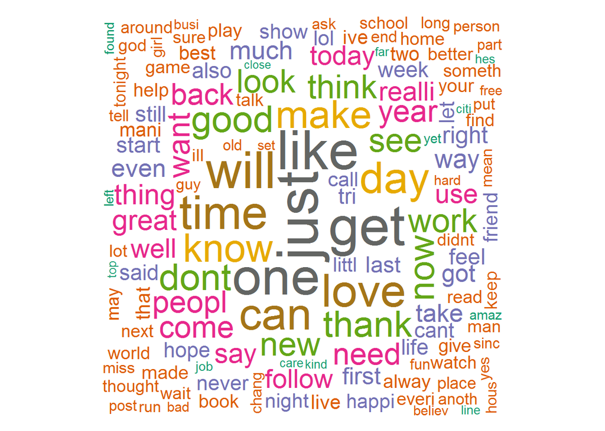

```r
wordcloud(corpusData, max.words = 250, random.order = FALSE, colors=brewer.pal(8,"Dark2"))
```